# Title: Budget, Genre, and Profit Trends: An Analytical Report on Movie Profitability

# Boxplot Outlier Detection and check Skewness

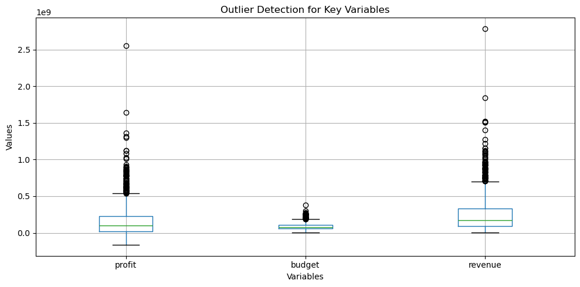

```
profit     2.767064
budget     1.544549
revenue    2.583470
dtype: float64
```

```python
cols_to_check = ['profit', 'budget', 'revenue']

plt.figure(figsize=(10,5))

df[cols_to_check].boxplot()

plt.title("Outlier Detection for Key Variables")
plt.xlabel("Variables")
plt.ylabel("Values")

plt.tight_layout()
plt.show()
df[cols_to_check].skew()
```

**The selected financial columns (profit, budget, and revenue) are visualized using a boxplot to identify outliers and understand data distribution through skewness. The plot is displayed using matplotlib.**

# Transform Boxplot Outlier Detection and check Skewness

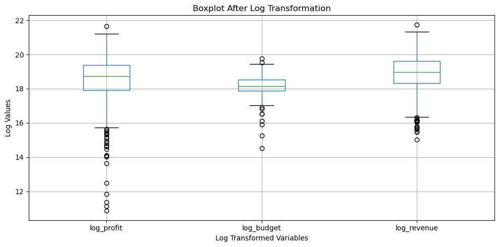

```
log_profit    -1.387581
log_budget    -0.411864
log_revenue   -0.507215
dtype: float64
```

```python
import warnings
warnings.filterwarnings('ignore')

cols = ['profit', 'budget', 'revenue']
df[cols].skew()

import numpy as np

df['log_profit'] = np.log1p(df['profit'])
df['log_budget'] = np.log1p(df['budget'])
df['log_revenue'] = np.log1p(df['revenue'])

plt.figure(figsize=(10,5))

df[['log_profit','log_budget','log_revenue']].boxplot()

plt.title("Boxplot After Log Transformation")
plt.xlabel("Log Transformed Variables")
plt.ylabel("Log Values")

plt.tight_layout()
plt.show()
df[['log_profit', 'log_budget', 'log_revenue']].skew()
```

**Explanation:This code checks the skewness of profit, budget, and revenue columns to understand data distribution. It then applies a log transformation using np.log1p() to reduce skewness and handle extreme values (outliers). After transformation, a boxplot is created to visualize the data and confirm that outliers have been reduced. Finally, skewness is calculated again to verify improvement in data distribution.**

# Heatmap

```
                    budget   revenue    profit  api_popularity  api_rating  \
budget            1.000000  0.633680  0.505232        0.228487    0.109795
revenue           0.633680  1.000000  0.987755        0.413846    0.355638
profit            0.505232  0.987755  1.000000        0.415587    0.374589
api_popularity    0.228487  0.413846  0.415587        1.000000    0.287121
api_rating        0.109795  0.355638  0.374589        0.287121    1.000000
vote_count        0.509854  0.761125  0.746251        0.461776    0.514150
year              0.340261  0.227916  0.185632        0.026095   -0.030487
wiki_page_length  0.359329  0.434387  0.412114        0.219603    0.232516

                  vote_count      year  wiki_page_length
budget              0.509854  0.340261          0.359329
revenue             0.761125  0.227916          0.434387
profit              0.746251  0.185632          0.412114
api_popularity      0.461776  0.026095          0.219603
api_rating          0.514150 -0.030487          0.232516
vote_count          1.000000  0.297020          0.428480
year                0.297020  1.000000          0.047063
wiki_page_length    0.428480  0.047063          1.000000
```

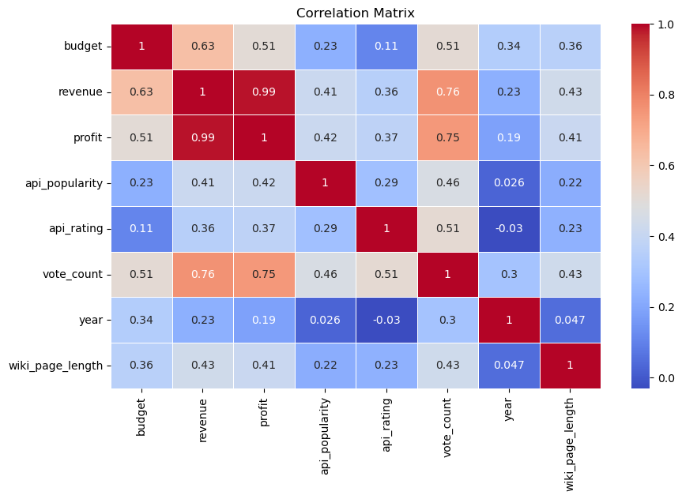

```python
import seaborn as sns
import matplotlib.pyplot as plt

cols = [
    'budget', 'revenue', 'profit',
    'api_popularity', 'api_rating',
    'vote_count', 'year', 'wiki_page_length'
]

corr = df[cols].corr()

print(corr)

plt.figure(figsize=(10,6))
sns.heatmap(corr, annot=True, cmap='coolwarm', linewidths=0.5)
plt.title("Correlation Matrix")
plt.show()
```

**This code computes and visualizes the correlation matrix of selected numerical variables using a heatmap to understand relationships between features.**

```python
from statsmodels.stats.outliers_influence import variance_inflation_factor
import pandas as pd
import statsmodels.api as sm

# 1. وہی X متغیرات استعمال کریں جو آپ نے Regression میں استعمال کیے تھے
X = df[['log_budget', 'api_rating', 'api_popularity', 'vote_count', 'wiki_page_length']]

# 2. Constant (Intercept) شامل کریں (VIF کے لیے ضروری ہے)
X_const = sm.add_constant(X)

# 3. VIF کا حساب لگائیں
vif_data = pd.DataFrame()
vif_data["Feature"] = X_const.columns
vif_data["VIF"] = [variance_inflation_factor(X_const.values, i) for i in range(X_const.shape[1])]

# 4. نتائج پرنٹ کریں
print("\n" + "="*50)
print("VIF (Multicollinearity Check)")
print("="*50)
print(vif_data)
print("\nNote: VIF > 5 (or 10) indicates high multicollinearity.")
```

```
==================================================
VIF (Multicollinearity Check)
==================================================
            Feature          VIF
0             const  2031.214737
1        log_budget     1.352703
2        api_rating     1.423628
3    api_popularity     1.277462
4        vote_count     2.149826
5  wiki_page_length     1.253734

Note: VIF > 5 (or 10) indicates high multicollinearity.
```